# NYC Flights EDA

2022-06-22

## Atrributes description

[output not shown]

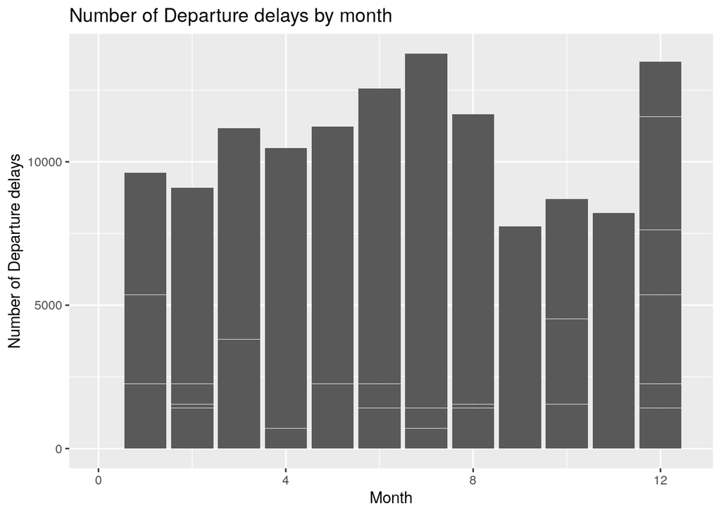

[figure not shown]

We can see from the plot above hat the highest number of departure delays occur on month 6 (Jun), 7 (Jul), and 12 (Dec) which indicate there are more departure delays during summer and winter breaks.

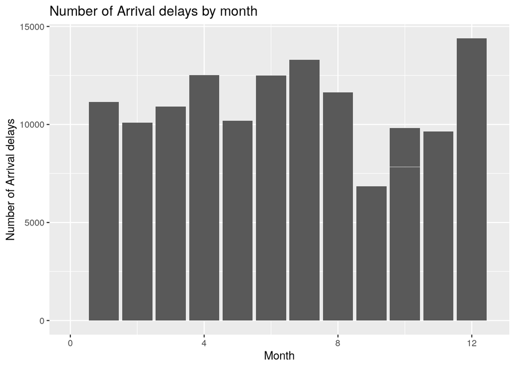

similar to the previous plot, here we see highest number of arrival delays occur on month 7 (Jul), and 12 (Dec) during the summer and winter breaks.

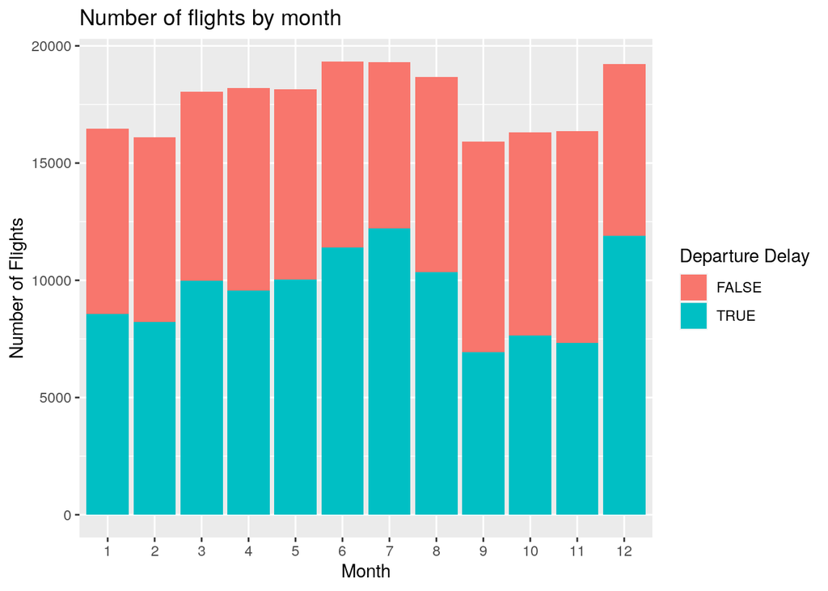

In this plot we can see that as the number of flights increases, the number of departure delays also increase. If we check for the months with the highest delays, 6 (Jun), 7 (Jul), and 12 (Dec). We see they also have the highest number of flights compared to other months.

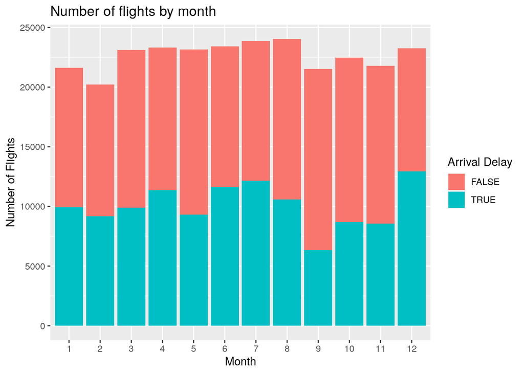

Here, it’s similar to the plot above where the number of flights increases, the number of Arrival delays also increase. Except that for month 8 (Aug), where the number of flights were high but the arrival delays were relatively lower than months with less flights.